# Global effect of temperature on the concentration of secondary compounds from brown seaweeds

05 junho, 2019

## Background

Understanding brown seaweed macroecological patterns is a challenge. Many macroecological patterns are yet to be described and there is still a lack of mechanistic explanations for the few known patterns. For instance, evidence suggests that there is a peak of brown algae diversity in higher latitudes (Santelices et al 2009). Suggested explanations for such patterns rely on biogeographical and competitive mechanisms. It has been suggested that brown algae evolved and diversified in cooler seas because of temperature tolerance. In addition, because some brown seaweed such as kelp and factoids are considered successful competitors in cooler seas, they might exclude green and red algal species what could generate observed patterns of global diversity.

General patterns of brown seaweeds are also driven by the effect of herbivores. As a protection against grazing, brown seaweeds produce chemical defenses such as phenolic compounds. Because of the global pattern of distribution of brown seaweeds, higher concentrations of phenolic compounds are also expected to be found at higher latitudes (Steinberg and Paul 1990; Steinberg et al. 1991). At local scales, environmental gradients of salinity and photosynthetically active radiation are important components driving the pattern of phenolic compounds produced by brown seaweed (Hess et al. 2017). Although there are global predictions for patterns of phenolic compounds produced by seaweed, to our knowledge this is the fist study that aimed to describe patterns of phenolic compounds concentration at a global scale.

The goal of our study is to understand global patterns of phenolic compounds produced by brown seaweeds. Because of phenolic patterns can be affect by multiple factors, such as temperature from a biogeographical viewpoint or salinity and radiation from a environmental gradient viewpoint, we present three distinct hypotheses. Our first hypothesis is that because of biogeograhic processes affecting seaweed distribution, concentration of phenolic compounds if negatively related to sea temperature. Given that environmental gradients can affect the concentration of phenolic compounds, our second hypothesis is that concentration of phenolic compounds is related to environmental gradients of salinity and photossyntetically active radiation. Finally, we hypothesize that concentration of phenolic compounds can be affected by both temperature and local environmental gradients of salinity and photossyntetically active radiation.

## Methods

### Data set

In order to understand variables affecting phlototannin concentration, we used both the mean and the coefficient of variation (CV) of phlonotannin concentration produced by a species as response variables. Given that brown algae occur predominantly at cooler seas and extreme temperatures should be determinant for its occurrence we chose to represent the variable temperature by maximum and range temperature at minimum depth for both the mean and CV of phlorotannin concentration, respectively. At each study locality we extracted from Bio-Oracle (Tyberghein et al. 2012, Assis et al. 2017) the following variables: sea water maximum temperature at minimum depth, sea water range temperature at minimum depth, salinity and photossyntetically active radiation (PAR).

### Statistical analysis

We used linear mixed models (LMMs) with spatial auto correlated random effects to examine the effects of different combinations of variables on concentration of phlorotannin recorded at each site. In order to account for spatial auto correlated random effects we used the procedure proposed by Rousset and Ferdy 2014 which estimates model parameters based on Laplace approximations for the likelihood with a Matérn model (Stein 1999) for spatial correlation. Our three hypotheses and a null hypothesis were represented by different sets of models (Table 1). The hypothesis that phlorotannin concentration is affected by biogeographical processes was represented by three models: one with temperature, one with ocean region and another one with the additive effect of temperature and ocean region. We added ocean region to account for differences in the response in different biogeographical regions that could occur besides the effect of temperature. The hypothesis that phlorotannin concentration is affected by environmental gradients of salinity and PAR was represented by one additive model with the two variables. The hypothesis that phlototannin concentration is affected by both biogegraphical and environmental gradient effects was represented by three models in which we combined all biogeographical models with the the environmental gradient model.

Table 1. Hypotheses and models representing each hypotheses. All models retained (1|Species) and (1|References) as random effects, as well as the Mátern model for spatial auto correlation.

| Hypotheses | Models |
| --- | --- |
| Biogeographical hypothesis | ~ Temperature + Ocean |
|  | ~ Temperature |
|  | ~ Ocean |
| Environmental gradient hypothesis | ~ Salinity + PAR |
| Biogegraphical and environmental gradient hypothesis | ~ Temperature + Ocean + Salinity + PAR |
|  | ~ Temperature + Salinity + PAR |
|  | ~ Ocean + Salinity + PAR |
| Null hypothesis | ~ 1 |

We followed the protocol of Zuur et al. (2009) to construct and test LMMs fitted to nested and hierarchical data (i.e.replicates distributed over species and publications). Because First, we built six LMMs using combinations of random variables and selected the model with the best random effects structure (using all fixed effects). We then used this selected random effects structure to identify the best set of fixed effects predictors (Table S2). In all models, the response variable was the mean value of phlorotannin concentration (log-transformed). Ocean region, temperature and their additive and interactive effects were tested as fixed effect predictors. The additive effects hypothesis assumes that both variables could influence phlorotannin concentration, but that these effects are independent. The interactive effects hypothesis assumes that ocean region and temperature interact to affect phlorotannin concentration. Based on our previous random effect model selection, species and publication identities were included in models as random effects.

## Results

We found that phlorotannin concentration is negatively affected by maximum temperature. Best model retained only temperature as a fixed effect (Table 1, Figure 1).

Table 1. Model selection results for fixed effects of temperature (Temp), oceanic region (Ocean), and their interaction (Temp:Ocean) based on the random effect structure: random intercept effect of species and random intercept effect of study author. Models were ranked based on differences in Akaike’s information criterion (AIC). k is the number of parameters in the model and w is the Akaike weight of each model.

| Model | $\Delta$AIC | k | w | AIC |
| --- | --- | --- | --- | --- |
| Temp | 0.000000 | 2 | 0.894 | 1357.095 |
| Temp + Ocean | 4.797067 | 5 | 0.081 | 1361.892 |
| Null | 7.802578 | 1 | 0.018 | 1364.897 |
| Temp:ocean + Temp + Ocean | 10.384029 | 8 | 0.005 | 1367.479 |
| Ocean | 13.255751 | 4 | 0.001 | 1370.350 |

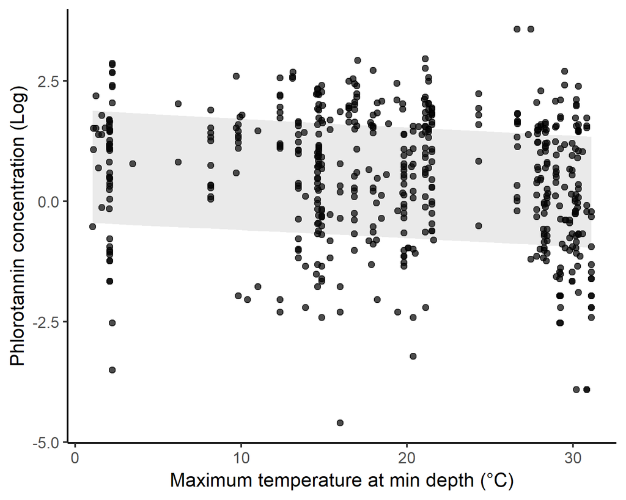

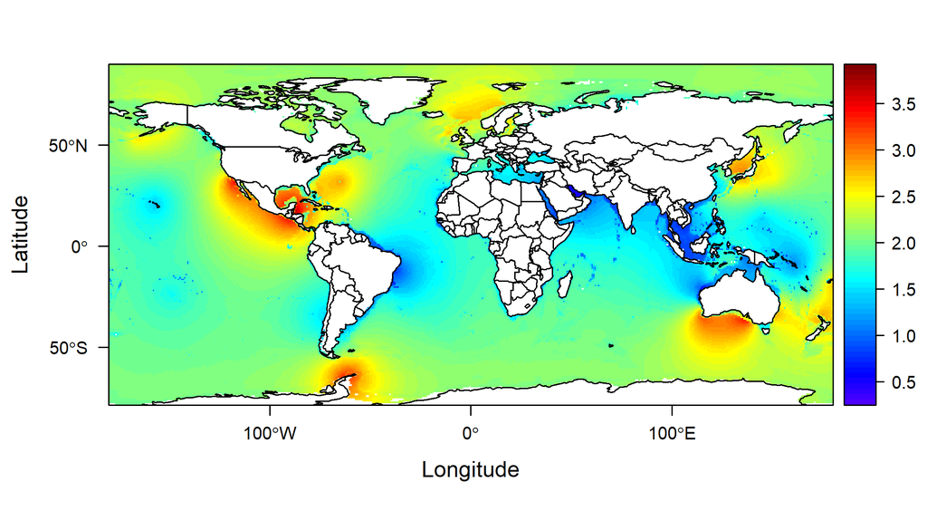

Figure 2. Prediction of phlorotannin concentration at a global scale.

```r
stable1 <- read.csv("../results/S_table_01.csv")
#stable1$Scientific.name <- paste0("*", stable1$Scientific.name, "*")
knitr::kable(stable1)
```

| Ocean | Longitude | Latitude | Scientific.name | Order | Mean | CV | Reference |
| --- | --- | --- | --- | --- | --- | --- | --- |
| North Atlantic | -10.416667 | 53.150000 | Himanthalia elongata | Fucales | 2.79 | 0.1971326 | Quéguineur et al. 2013 |
| North IP | -117.783333 | 33.533333 | Egregia menziesii | Laminariales | 0.50 | 0.6400000 | Wakefield & Murray 1998 |
| North IP | -118.350000 | 33.383333 | Cystoseira neglecta | Fucales | 1.37 | 0.5693431 | Van Alstyne et al. 1999a |
| North IP | -118.350000 | 33.383333 | Egregia menziesii | Laminariales | 2.16 | 0.2777778 | Van Alstyne et al. 1999a |
| North IP | -118.350000 | 33.383333 | Eisenia arborea | Laminariales | 5.02 | 0.1454183 | Van Alstyne et al. 1999a |
| North IP | -118.350000 | 33.383333 | Halidrys dioica | Fucales | 4.14 | 0.7729469 | Van Alstyne et al. 1999a |
| North IP | -118.350000 | 33.383333 | Hesperophycus harveyanus | Fucales | 1.09 | 0.2660550 | Van Alstyne et al. 1999a |
| North IP | -118.350000 | 33.383333 | Macrocystis pyrifera | Laminariales | 1.04 | 0.3557692 | Van Alstyne et al. 1999a |
| North IP | -118.350000 | 33.383333 | Sargassum palmeri | Fucales | 1.31 | 0.3358779 | Van Alstyne et al. 1999a |
| North IP | -118.350000 | 33.383333 | Egregia menziesii | Laminariales | 1.38 | 0.5434783 | Van Alstyne et al. 1999b |
| North IP | -118.350000 | 33.383333 | Eisenia arborea | Laminariales | 4.59 | 0.1917211 | Van Alstyne et al. 1999b |
| North IP | -118.350000 | 33.383333 | Eisenia arborea | Laminariales | 6.68 | 0.1452096 | Van Alstyne et al. 1999b |
| North IP | -118.350000 | 33.383333 | Egregia menziesii | Laminariales | 2.10 | 0.2857143 | Van Alstyne et al. 1999b |
| North IP | -118.416667 | 33.750000 | Halidrys dioica | Fucales | 3.80 | 0.4157895 | Wakefield & Murray 1998 |
| North IP | -118.416667 | 33.750000 | Eisenia arborea | Laminariales | 3.50 | 0.3600000 | Wakefield & Murray 1998 |
| North IP | -118.416667 | 33.750000 | Macrocystis pyrifera | Laminariales | 1.40 | 0.2285714 | Wakefield & Murray 1998 |
| North IP | -118.416667 | 33.750000 | Dictyopteris prolifera | Dictyotales | 15.18 | NA | Yang et al. 2014 |
| North IP | -119.000000 | 38.000000 | Macrocystis pyrifera | Laminariales | 1.22 | 0.1885246 | Targett et al. 1992 |
| North IP | -120.666667 | 34.616667 | Fucus distichus | Fucales | 4.75 | 0.1052632 | Arnold & Targett 1998 |
| North IP | -120.000000 | 47.000000 | Nereocystis luetkeana | Laminariales | 0.52 | 0.0192308 | Targett et al. 1992 |
| North IP | -120.000000 | 47.000000 | Fucus distichus | Fucales | 4.12 | 0.0922330 | Targett et al. 1992 |
| North IP | -121.216667 | 35.650000 | Pelvetia fastigiata | Fucales | 5.98 | 0.1655518 | Van Alstyne et al. 1999a |
| North IP | -121.216667 | 35.650000 | Egregia menziesii | Laminariales | 0.40 | 0.3000000 | Van Alstyne et al. 1999a |
| North IP | -121.216667 | 35.650000 | Laminaria dentigera | Laminariales | 0.37 | 0.2162162 | Van Alstyne et al. 1999a |
| North IP | -121.216667 | 35.650000 | Laminaria sinclairii | Laminariales | 0.37 | 0.1351351 | Van Alstyne et al. 1999a |
| North IP | -121.933333 | 36.633333 | Egregia menziesii | Laminariales | 0.58 | 0.3965517 | Van Alstyne et al. 1999a |
| North IP | -121.933333 | 36.633333 | Laminaria farlowii | Laminariales | 4.60 | 0.1000000 | Van Alstyne et al. 1999a |
| North IP | -121.933333 | 36.633333 | Macrocystis pyrifera | Laminariales | 1.31 | 0.1984733 | Van Alstyne et al. 1999a |
| North IP | -121.933333 | 36.633333 | Cystoseira osmundacea | Fucales | 1.60 | 0.3937500 | Van Alstyne et al. 1999a |
| North IP | -121.933333 | 36.633333 | Egregia menziesii | Laminariales | 0.75 | 0.6666667 | Van Alstyne et al. 1999b |

[output cut: 497 more lines]